# Apply ENIGMA to resolve latent cell type specific states

Weixu Wang

2021/9/15

## Introduction

This tutorial introduce how to use ENIGMA to resolve cell type-specific expression (CSE) profile and benchmark ENIGMA with other methods. We hope use ENIGMA could help us detect cell type-specific sample-wise correlation structure to decipher latent cell expression heterogeneity on population level.

## Simulate CSE and constitute in silico mixture

To show ENIGMA could resolve the signal, we first use splatter to simulate the CSE with specific clustering structure.

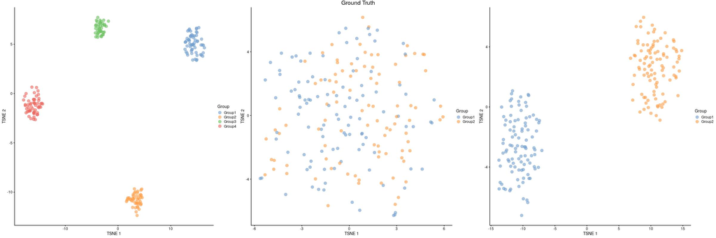

```r
# loading the packages we need
suppressPackageStartupMessages(library(scater))
suppressPackageStartupMessages(library(splatter))
suppressPackageStartupMessages(library(ENIGMA))
suppressPackageStartupMessages(library(cowplot))

## Simulate CSE
params <- newSplatParams(seed=2022)
params <- setParams(params, update = list(nGenes = 8368, batchCells=200))
sim.groups.c1 <- splatSimulateGroups(params,
                                     group.prob = c(0.25,0.25,0.25,0.25),
                                     de.prob = c(0.3),
                                     verbose = FALSE)
sim.groups.c1 <- logNormCounts(sim.groups.c1)
sim.groups.c1 <- runPCA(sim.groups.c1)
sim.groups.c1 <- runTSNE(sim.groups.c1,dimred="PCA",n_dimred=5)
p_c1 <- plotTSNE(sim.groups.c1, colour_by = "Group",point_size=3)
label.c1 <- sim.groups.c1$Group


params <- newSplatParams(seed=1002)
params <- setParams(params, update = list(nGenes = 8368, batchCells=200))
sim.groups.c2 <- splatSimulateGroups(params,
                                     group.prob = c(0.5,0.5),
                                     de.prob = c(0.01),
                                     verbose = FALSE)
sim.groups.c2 <- logNormCounts(sim.groups.c2)
sim.groups.c2 <- runPCA(sim.groups.c2)
sim.groups.c2 <- runTSNE(sim.groups.c2,dimred="PCA",n_dimred=5)
p_c2 <- plotTSNE(sim.groups.c2, colour_by = "Group",point_size=3)
label.c2 <- sim.groups.c2$Group

params <- newSplatParams(seed=1004)
params <- setParams(params, update = list(nGenes = 8368, batchCells=200))
sim.groups.c3 <- splatSimulateGroups(params,
                                     group.prob = c(0.5,0.5),
                                     de.prob = c(0.1),
                                     verbose = FALSE)
sim.groups.c3 <- logNormCounts(sim.groups.c3)
sim.groups.c3 <- runPCA(sim.groups.c3)
sim.groups.c3 <- runTSNE(sim.groups.c3,dimred="PCA",n_dimred=5)
p_c3 <- plotTSNE(sim.groups.c3, colour_by = "Group",point_size=3)
label.c3 <- sim.groups.c3$Group

p_true <- plot_grid(p_c1,p_c2,p_c3,nrow=1)
p_true <- p_true + ggtitle("Ground Truth") +
    theme(plot.title = element_text(hjust = 0.5))
p_true
```

We could see that the first CSE have four distinct clusters, and third CSE have two clusters. I also simulate CSE (second CSE) with subtle variations across clusters. Then I simulate cell type-specific fractions, and doing linear combinations with CSE to construct “bulk-samples”

```r
sim.groups.c1 <- counts(sim.groups.c1) %*% diag(10000/colSums(counts(sim.groups.c1)))
sim.groups.c2 <- counts(sim.groups.c2) %*% diag(10000/colSums(counts(sim.groups.c2)))
sim.groups.c3 <- counts(sim.groups.c3) %*% diag(10000/colSums(counts(sim.groups.c3)))

colnames(sim.groups.c2) <- colnames(sim.groups.c3) <- colnames(sim.groups.c1) <- paste0("Sample-",1:ncol(sim.groups.c1))

mat <- list(sim.groups.c1,sim.groups.c2,sim.groups.c3)
names(mat) <- c("ct1","ct2","ct3")
H1_array <- array(0,
                  dim = c( 3,
                           8368,
                           200))

### construct reference profile
H1 <- array(0,
                  dim = c( 3,
                           8368))
for(i in 1:3){
  H1_array[i,,] <- mat[[i]]
  H1[i,] <- rowMeans(mat[[i]])
}

k <- 3 # number of cell types
ng <- 8368 # number of genes
p <- 200 # number of samples

###Simulate cell type-specific fractions
cc <- matrix(runif(p*k), ncol=k)
cc <- t(scale(t(cc), center=FALSE, scale=rowSums(cc)))
colnames(cc) <- paste('cellType', 1:ncol(cc), sep="")


##evaluate differential expression genes
##calculate
G <- NULL
for(i in 1:200){
    G <- cbind(G, t(as.matrix(t(as.matrix(cc[i,])) %*% H1_array[,,i])))
}
```

I also add some noise to the expression profile to make this task harder.

```r
noise <- t(matrix(rnorm(p*ng)*15, ncol=ng))
noise[noise<0] <- 0
G <- G + noise
k <- apply(G,1,var) > 10^-8
G <- G[k,]
H1 <- H1[,k]
H1_array <- H1_array[,k,]

rownames(G) <- colnames(H1) <- paste0("gene",c(1:nrow(G)))
colnames(G) <- paste0("Sample",1:ncol(G))
rownames(H1) <- colnames(cc)
```

Finally, I have construct a bulk expression profile, and each CSE in this profile has latent clusters structures. Now lets see that whether we could detect the clusters structure on bulk sample levels.

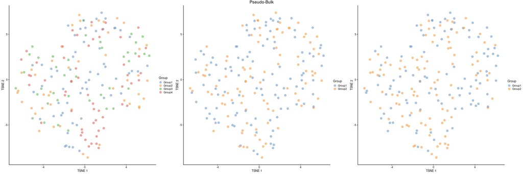

```r
raw <- SingleCellExperiment(assays=list(logcounts = G))
raw$Group <- label.c1
raw <- raw
raw <- runPCA(raw)
p <- plotPCA(raw, colour_by = "Group")
#raw <- runUMAP(raw,dimred="PCA",n_dimred=5)
#p_raw_umap <- plotUMAP(raw, colour_by = "Group",point_size=3)
raw <- runTSNE(raw,dimred="PCA",n_dimred=5)
p_raw1 <- plotTSNE(raw, colour_by = "Group",point_size=3)

raw$Group <- label.c2
p_raw2 <- plotTSNE(raw, colour_by = "Group",point_size=3)

raw$Group <- label.c3
p_raw3 <- plotTSNE(raw, colour_by = "Group",point_size=3)

p_raw <- plot_grid(p_raw1,p_raw2,p_raw3,nrow=1)
p_raw <- p_raw + ggtitle("Pseudo-Bulk") +
    theme(plot.title = element_text(hjust = 0.5))
p_raw
```

We could see that the bulk samples could not reveal any CSE specific clusters, suggest that the bulk expression profile would corrupt some biological meaningful signal.

## Using other methods to deconvolve bulk RNA-seq samples

Before I use ENIGMA to perform deconvolution, I first use TCA to perform deconvolution so that to support the superior performance of ENIGMA TCA is a deconvolution methods require input mixture profile and cell type fraction matrix. To run this algorithm, I first used robust linear regression model to fit the cell type specific fraction matrix.

```r
get_proportion <- function(X, ref) {
    cat( date(), "Calculating cell type proportion of bulk samples... \n" )
    gene_id = intersect( rownames(X), rownames(ref) )
    X_m = X[gene_id,]
    ref_m = ref[gene_id,]
    ref_m <- apply(ref_m,2,scale)
    theta <- NULL
    coefVec <- NULL
    for(i in 1:ncol(X_m)){
        Exp <- as.matrix(X_m[,i])
        rownames(Exp) <- rownames(ref_m)
        colnames(Exp) <- colnames(X_m)[i]
        Exp <- scale(Exp)

        rlm.o <- rlm(Exp ~ as.matrix(ref_m), maxit = 100)
        coef.v <- summary(rlm.o)$coef[2:(ncol(as.matrix(ref_m)) + 1), 1]
        coefVec <- rbind(coefVec,coef.v)
        coef.v[which(coef.v < 0)] <- 0
        total <- sum(coef.v)
        coef.v <- coef.v/total
        theta <- rbind(theta,coef.v)
    }
    colnames(theta) <- colnames(coefVec) <- colnames(ref_m)
    rownames(theta) <- rownames(coefVec) <- colnames(X_m)
    res <- list()
    res$theta <- theta
    return(res)
}
suppressPackageStartupMessages(library(MASS))
Fra_Simulate <- get_proportion(G, t(H1))
```

```
## Wed Sep 15 11:03:01 2021 Calculating cell type proportion of bulk samples...
```

Lets compare our fitting results with ground truth!

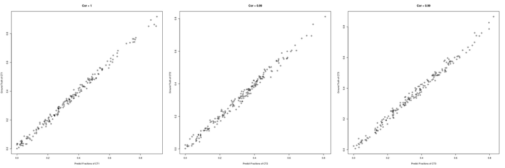

```r
par(mfrow=c(1,3))
plot(Fra_Simulate$theta[,1],cc[,1],main = paste("Cor = ",round(cor(Fra_Simulate$theta[,1],cc[,1]),2),sep=""),xlab="Predict Fractions of CT1",ylab="Ground Truth of CT1")
plot(Fra_Simulate$theta[,2],cc[,2],main = paste("Cor = ",round(cor(Fra_Simulate$theta[,2],cc[,2]),2),sep=""),xlab="Predict Fractions of CT2",ylab="Ground Truth of CT2")
plot(Fra_Simulate$theta[,3],cc[,3],main = paste("Cor = ",round(cor(Fra_Simulate$theta[,3],cc[,3]),2),sep=""),xlab="Predict Fractions of CT3",ylab="Ground Truth of CT3")
```

We could see that all fractions show perfect fitness with ground truth, now lets see the CSE deconvolution!

```r
suppressPackageStartupMessages(library(TCA))
bulk <- G
time.tca <- system.time({tca.mdl <- tca(X = bulk, W = Fra_Simulate$theta, C1 = NULL, C2 = NULL,
                parallel = TRUE,num_cores=4,max_iters=5)
Z_hat_simulate <- tensor(X = (as.matrix(bulk)), tca.mdl)})
```

```
## INFO [2021-09-15 11:03:07] Starting tca...
## INFO [2021-09-15 11:03:07] Validating input...
## INFO [2021-09-15 11:03:07] Fitting the TCA model...
## INFO [2021-09-15 11:03:07] Fitting means and variances...
## INFO [2021-09-15 11:03:08] Iteration 1 out of 5 internal iterations...
## INFO [2021-09-15 11:03:59] Iteration 2 out of 5 internal iterations...
## INFO [2021-09-15 11:04:34] Internal loop converged.
## INFO [2021-09-15 11:04:34] Finished tca.
## INFO [2021-09-15 11:04:34] Starting tensor for estimating Z...
## INFO [2021-09-15 11:04:34] Estimate tensor...
## INFO [2021-09-15 11:05:19] Finished estimating tensor.
```

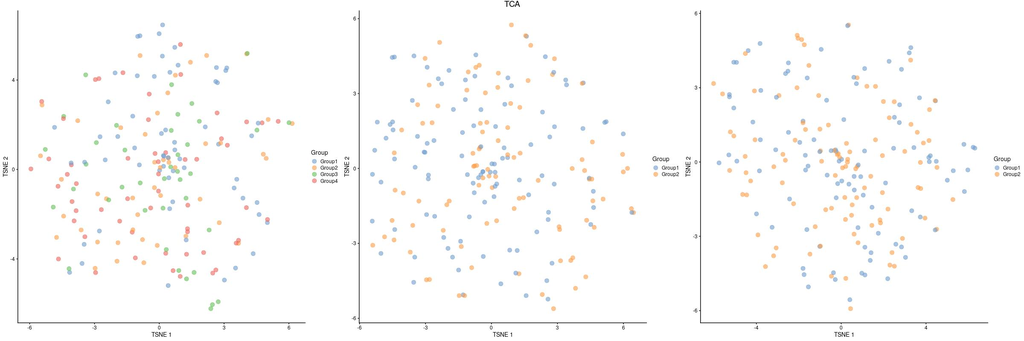

```r
TCA <- SingleCellExperiment(assays=list(logcounts = Z_hat_simulate[[1]]))
TCA$Group <- label.c1
TCA <- TCA[Fra_Simulate$theta[,1]>0.05]
TCA <- runPCA(TCA)
p <- plotPCA(TCA, colour_by = "Group")
#TCA <- runUMAP(TCA,dimred="PCA",n_dimred=5)
#p_TCA_umap <- plotUMAP(TCA, colour_by = "Group",point_size=3)
TCA <- runTSNE(TCA,dimred="PCA",n_dimred=5)
p_TCA_tsne1 <- plotTSNE(TCA, colour_by = "Group",point_size=3)

TCA <- SingleCellExperiment(assays=list(logcounts = Z_hat_simulate[[2]]))
TCA$Group <- label.c2
TCA <- TCA[Fra_Simulate$theta[,2]>0.05]
TCA <- runPCA(TCA)
p <- plotPCA(TCA, colour_by = "Group")
#TCA <- runUMAP(TCA,dimred="PCA",n_dimred=5)
#p_TCA_umap <- plotUMAP(TCA, colour_by = "Group",point_size=3)
TCA <- runTSNE(TCA,dimred="PCA",n_dimred=5)
p_TCA_tsne2 <- plotTSNE(TCA, colour_by = "Group",point_size=3)


TCA <- SingleCellExperiment(assays=list(logcounts = Z_hat_simulate[[3]]))
TCA$Group <- label.c3
TCA <- TCA[Fra_Simulate$theta[,3]>0.05]
TCA <- runPCA(TCA)
p <- plotPCA(TCA, colour_by = "Group")
#TCA <- runUMAP(TCA,dimred="PCA",n_dimred=5)
#p_TCA_umap <- plotUMAP(TCA, colour_by = "Group",point_size=3)
TCA <- runTSNE(TCA,dimred="PCA",n_dimred=5)
p_TCA_tsne3 <- plotTSNE(TCA, colour_by = "Group",point_size=3)

p_TCA <- plot_grid(p_TCA_tsne1,p_TCA_tsne2,p_TCA_tsne3,nrow=1)
p_TCA <- p_TCA + ggtitle("TCA") +
    theme(plot.title = element_text(hjust = 0.5))
p_TCA
```

We could see that TCA could not preserve the latent CSE sample level correlation structure.

## Using ENIGMA to resolve bulk samples

To use ENIGMA infer CSE, I first build a ENIGMA object.

```r
G <- as.matrix(G)
H1 <- as.matrix(H1)
egm = create_ENIGMA(bulk = G, ref = t(H1), ref_type = "bulk", meta_ref = as.matrix(colnames(t(H1))))
```

```
## Wed Sep 15 11:05:22 2021 Reference from FACS Bulk RNA-seq/microarray.
```

```r
egm = batch_correct(egm)
```

```
## Wed Sep 15 11:05:22 2021 Reference is from FACS Bulk RNA-seq/microarray, doing batch correction in B mode.
```

```
## Wed Sep 15 11:05:27 2021 Run B-mode to correct batch effect...
## Wed Sep 15 11:05:27 2021 Doing ComBat...
```

```
## Found2batches
```

```
## Adjusting for0covariate(s) or covariate level(s)
```

```
## Standardizing Data across genes
```

```
## Fitting L/S model and finding priors
```

```
## Finding parametric adjustments
```

```
## Adjusting the Data
```

```
## Wed Sep 15 11:05:30 2021 Done.
```

```r
## Here we don't need batch effect correction therefore I set the correct bulk expression profile back to the raw!
egm@bulk <- G

## Caculate cell type-specific fractions
egm = get_cell_proportion(egm)
```

```
## Wed Sep 15 11:05:30 2021 Calculating cell type proportion of bulk samples...
```

```r
## Using ENIGMA to infer CSE
egm = ENIGMA_L2_max_norm(egm, epsilon=0.001, alpha=0.7,
                        beta=4500,tao_k=0.01,max.iter=1000,verbose=TRUE)
```

```
## Wed Sep 15 11:05:35 2021 Optimizing cell type specific expression profile...
##    Ratio ranges from: 590368.044457 - 606987.118210
##    Ratio ranges from: 125294.253281 - 142714.334567
##    Ratio ranges from: 57059.431985 - 69428.961261
##    Ratio ranges from: 36497.197928 - 43326.888545
##    Ratio ranges from: 23775.983415 - 27325.949885
##    Ratio ranges from: 15720.666195 - 17456.990803
##    Ratio ranges from: 10663.527585 - 11789.493621
##    Ratio ranges from: 7493.896752 - 8326.333065
##    Ratio ranges from: 5476.511227 - 6125.062189
##    Ratio ranges from: 4147.464736 - 4664.783534
##    Ratio ranges from: 3196.264413 - 3644.185959
##    Ratio ranges from: 2505.319744 - 2894.998516
##    Ratio ranges from: 1987.402212 - 2323.725967
##    Ratio ranges from: 1586.567263 - 1876.746401
##    Ratio ranges from: 1270.343951 - 1521.302276
##    Ratio ranges from: 1018.277023 - 1235.827057
##    Ratio ranges from: 816.343794 - 1005.155547
##    Ratio ranges from: 654.254726 - 818.089756
##    Ratio ranges from: 524.102961 - 666.072095
##    Ratio ranges from: 419.642344 - 542.402509
##    Ratio ranges from: 335.865944 - 441.746316
##    Ratio ranges from: 268.734036 - 359.808833
##    Ratio ranges from: 214.981004 - 293.109548
##    Ratio ranges from: 171.968110 - 238.817629
##    Ratio ranges from: 137.566306 - 194.626896
##    Ratio ranges from: 110.060969 - 158.657700
##    Ratio ranges from: 88.073829 - 129.378299
##    Ratio ranges from: 70.498904 - 105.541052
##    Ratio ranges from: 56.450037 - 86.130305
##    Ratio ranges from: 45.218081 - 70.319726
##    Ratio ranges from: 36.236105 - 57.437327
##    Ratio ranges from: 29.051198 - 46.936840
##    Ratio ranges from: 23.301735 - 38.374303
##    Ratio ranges from: 18.699064 - 31.388936
##    Ratio ranges from: 15.012821 - 25.687559
##    Ratio ranges from: 12.059160 - 21.031901
##    Ratio ranges from: 9.691343 - 17.228270
##    Ratio ranges from: 7.792226 - 14.119175
##    Ratio ranges from: 6.268265 - 11.576513
```

[output cut: 37 more lines]

```
##    Ratio ranges from: 0.002058 - 0.007694
##    Ratio ranges from: 0.001673 - 0.006370
##    Ratio ranges from: 0.001361 - 0.005274
##    Ratio ranges from: 0.001106 - 0.004367
##    Ratio ranges from: 0.000900 - 0.003616
##    Ratio ranges from: 0.000732 - 0.002995
##    Ratio ranges from: 0.000596 - 0.002481
##    Ratio ranges from: 0.000485 - 0.002055
##    Ratio ranges from: 0.000394 - 0.001702
##    Ratio ranges from: 0.000321 - 0.001410
##    Ratio ranges from: 0.000261 - 0.001169
##    Ratio ranges from: 0.000213 - 0.000968
## Total loss: 201899027.934732
## part1:3726650.05625428 part2:3207710.31284384 part3:43539.3290354415
## Perform Normalization...Wed Sep 15 11:10:03 2021 Done...
```

Then we visualize if ENIGMA could reconstruct the CSE and preserve the latent sample-wise correlation structure.

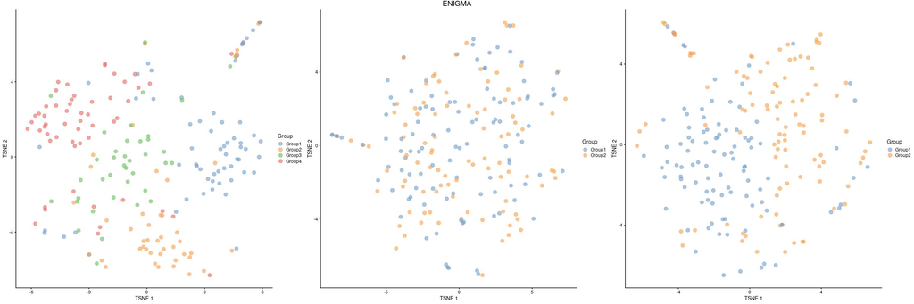

```r
enigma <- egm@result_CSE_normalized[,egm@result_CSE_normalized$cell_type %in% "cellType1"]
enigma$Group <- label.c1
enigma <- enigma[Fra_Simulate$theta[,1]>0.05]
enigma <- runPCA(enigma)
p <- plotPCA(enigma, colour_by = "Group")
#enigma <- runUMAP(enigma,dimred="PCA",n_dimred=5)
#p_enigma_umap <- plotUMAP(enigma, colour_by = "Group",point_size=3)
enigma <- runTSNE(enigma,dimred="PCA",n_dimred=5)
p_enigma_tsne1 <- plotTSNE(enigma, colour_by = "Group",point_size=3)


enigma <- egm@result_CSE_normalized[,egm@result_CSE_normalized$cell_type %in% "cellType3"]
enigma$Group <- label.c3
enigma <- enigma[Fra_Simulate$theta[,3]>0.05]
enigma <- runPCA(enigma)
p <- plotPCA(enigma, colour_by = "Group")
#enigma <- runUMAP(enigma,dimred="PCA",n_dimred=5)
#p_enigma_umap <- plotUMAP(enigma, colour_by = "Group",point_size=3)
enigma <- runTSNE(enigma,dimred="PCA",n_dimred=5)
p_enigma_tsne3 <- plotTSNE(enigma, colour_by = "Group",point_size=3)


enigma <- egm@result_CSE_normalized[,egm@result_CSE_normalized$cell_type %in% "cellType2"]
enigma$Group <- label.c2
enigma <- enigma[Fra_Simulate$theta[,2]>0.05]
enigma <- runPCA(enigma)
p <- plotPCA(enigma, colour_by = "Group")
#enigma <- runUMAP(enigma,dimred="PCA",n_dimred=5)
#p_enigma_umap <- plotUMAP(enigma, colour_by = "Group",point_size=3)
enigma <- runTSNE(enigma,dimred="PCA",n_dimred=5)
p_enigma_tsne2 <- plotTSNE(enigma, colour_by = "Group",point_size=3)

p_enigma <- plot_grid(p_enigma_tsne1,p_enigma_tsne2,p_enigma_tsne3,nrow=1)
p_enigma <- p_enigma + ggtitle("ENIGMA") +
    theme(plot.title = element_text(hjust = 0.5))
p_enigma
```

We could see that ENIGMA could reconstruct CSE and also preserve the latent states. I also compare ENIGMA with other deconvolution methods on this task, check the https://github.com/WWXkenmo/ENIGMA/blob/main/cell_heterogeneity.R to reproduce our analyses.